# Lab #8

WEI-XUAN HU

2024-03-23

## 0.

### Install packages require and load the data.

```r
library(raster)

library(sf)

watershed <- st_read("Wildcat_Creek_Watershed.shp")
```

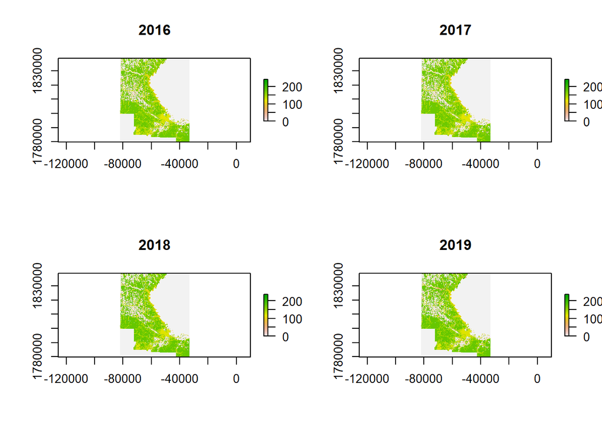

```r
CDL2016 <- raster("CDL_2016_20161.tif")
CDL2017 <- raster("CDL_2017_20161.tif")
CDL2018 <- raster("CDL_2018_20161.tif")
CDL2019 <- raster("CDL_2019_20161.tif")

# Take a look.

attach(mtcars)
par(mfrow=c(2,2))
plot(CDL2016, main = "2016")
plot(CDL2017, main = "2017")
plot(CDL2018, main = "2018")
plot(CDL2019, main = "2019")
```

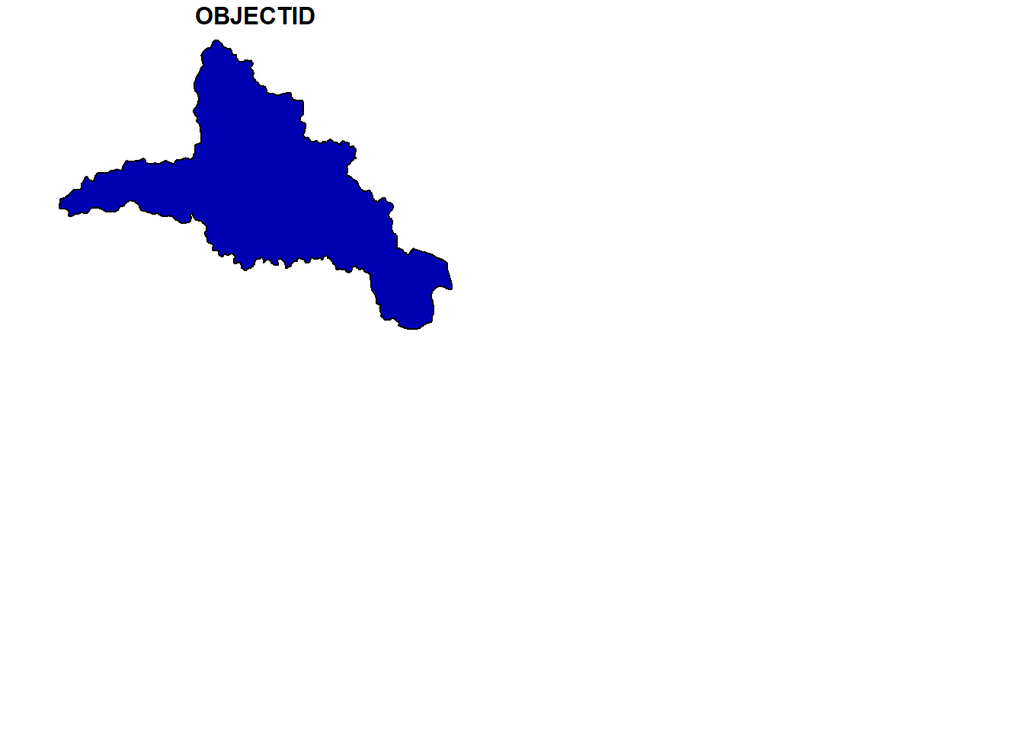

```r
plot(watershed[,1])
```

```r
#check CRS
crs(CDL2016)
```

```
## Coordinate Reference System:
## Deprecated Proj.4 representation:
##  +proj=aea +lat_0=23 +lon_0=-96 +lat_1=29.5 +lat_2=45.5 +x_0=0 +y_0=0
## +datum=NAD83 +units=m +no_defs
## WKT2 2019 representation:
## PROJCRS["unknown",
##     BASEGEOGCRS["unknown",
##         DATUM["North American Datum 1983",
##             ELLIPSOID["GRS 1980",6378137,298.257222101,
##                 LENGTHUNIT["metre",1]],
##             ID["EPSG",6269]],
##         PRIMEM["Greenwich",0,
##             ANGLEUNIT["degree",0.0174532925199433],
##             ID["EPSG",8901]]],
##     CONVERSION["unknown",
##         METHOD["Albers Equal Area",
##             ID["EPSG",9822]],
##         PARAMETER["Latitude of false origin",23,
##             ANGLEUNIT["degree",0.0174532925199433],
##             ID["EPSG",8821]],
##         PARAMETER["Longitude of false origin",-96,
##             ANGLEUNIT["degree",0.0174532925199433],
##             ID["EPSG",8822]],
##         PARAMETER["Latitude of 1st standard parallel",29.5,
##             ANGLEUNIT["degree",0.0174532925199433],
##             ID["EPSG",8823]],
##         PARAMETER["Latitude of 2nd standard parallel",45.5,
##             ANGLEUNIT["degree",0.0174532925199433],
##             ID["EPSG",8824]],
##         PARAMETER["Easting at false origin",0,
##             LENGTHUNIT["metre",1],
##             ID["EPSG",8826]],
##         PARAMETER["Northing at false origin",0,
##             LENGTHUNIT["metre",1],
##             ID["EPSG",8827]]],
##     CS[Cartesian,2],
##         AXIS["(E)",east,
##             ORDER[1],
##             LENGTHUNIT["metre",1,
##                 ID["EPSG",9001]]],
##         AXIS["(N)",north,
##             ORDER[2],
##             LENGTHUNIT["metre",1,
##                 ID["EPSG",9001]]]]
```

```r
crs(CDL2017)
```

```
## Coordinate Reference System:
## Deprecated Proj.4 representation:
##  +proj=aea +lat_0=23 +lon_0=-96 +lat_1=29.5 +lat_2=45.5 +x_0=0 +y_0=0
## +datum=NAD83 +units=m +no_defs
## WKT2 2019 representation:
## PROJCRS["unknown",
##     BASEGEOGCRS["unknown",
##         DATUM["North American Datum 1983",
##             ELLIPSOID["GRS 1980",6378137,298.257222101,
##                 LENGTHUNIT["metre",1]],
##             ID["EPSG",6269]],
##         PRIMEM["Greenwich",0,
##             ANGLEUNIT["degree",0.0174532925199433],
##             ID["EPSG",8901]]],
##     CONVERSION["unknown",
##         METHOD["Albers Equal Area",
##             ID["EPSG",9822]],
##         PARAMETER["Latitude of false origin",23,
##             ANGLEUNIT["degree",0.0174532925199433],
##             ID["EPSG",8821]],
##         PARAMETER["Longitude of false origin",-96,
##             ANGLEUNIT["degree",0.0174532925199433],
##             ID["EPSG",8822]],
##         PARAMETER["Latitude of 1st standard parallel",29.5,
##             ANGLEUNIT["degree",0.0174532925199433],
##             ID["EPSG",8823]],
##         PARAMETER["Latitude of 2nd standard parallel",45.5,
##             ANGLEUNIT["degree",0.0174532925199433],
##             ID["EPSG",8824]],
##         PARAMETER["Easting at false origin",0,
##             LENGTHUNIT["metre",1],
##             ID["EPSG",8826]],
##         PARAMETER["Northing at false origin",0,
##             LENGTHUNIT["metre",1],
##             ID["EPSG",8827]]],
##     CS[Cartesian,2],
##         AXIS["(E)",east,
##             ORDER[1],
##             LENGTHUNIT["metre",1,
##                 ID["EPSG",9001]]],
##         AXIS["(N)",north,
##             ORDER[2],
##             LENGTHUNIT["metre",1,
##                 ID["EPSG",9001]]]]
```

```r
crs(CDL2018)
```

```
## Coordinate Reference System:
## Deprecated Proj.4 representation:
##  +proj=aea +lat_0=23 +lon_0=-96 +lat_1=29.5 +lat_2=45.5 +x_0=0 +y_0=0
## +datum=NAD83 +units=m +no_defs
## WKT2 2019 representation:
## PROJCRS["unknown",
##     BASEGEOGCRS["unknown",
##         DATUM["North American Datum 1983",
##             ELLIPSOID["GRS 1980",6378137,298.257222101,
##                 LENGTHUNIT["metre",1]],
##             ID["EPSG",6269]],
##         PRIMEM["Greenwich",0,
##             ANGLEUNIT["degree",0.0174532925199433],
##             ID["EPSG",8901]]],
##     CONVERSION["unknown",
##         METHOD["Albers Equal Area",
##             ID["EPSG",9822]],
##         PARAMETER["Latitude of false origin",23,
##             ANGLEUNIT["degree",0.0174532925199433],
##             ID["EPSG",8821]],
##         PARAMETER["Longitude of false origin",-96,
##             ANGLEUNIT["degree",0.0174532925199433],
##             ID["EPSG",8822]],
##         PARAMETER["Latitude of 1st standard parallel",29.5,
##             ANGLEUNIT["degree",0.0174532925199433],
##             ID["EPSG",8823]],
##         PARAMETER["Latitude of 2nd standard parallel",45.5,
##             ANGLEUNIT["degree",0.0174532925199433],
##             ID["EPSG",8824]],
##         PARAMETER["Easting at false origin",0,
##             LENGTHUNIT["metre",1],
##             ID["EPSG",8826]],
##         PARAMETER["Northing at false origin",0,
##             LENGTHUNIT["metre",1],
##             ID["EPSG",8827]]],
##     CS[Cartesian,2],
##         AXIS["(E)",east,
##             ORDER[1],
##             LENGTHUNIT["metre",1,
##                 ID["EPSG",9001]]],
##         AXIS["(N)",north,
##             ORDER[2],
##             LENGTHUNIT["metre",1,
##                 ID["EPSG",9001]]]]
```

```r
crs(CDL2019)
```

```
## Coordinate Reference System:
## Deprecated Proj.4 representation:
##  +proj=aea +lat_0=23 +lon_0=-96 +lat_1=29.5 +lat_2=45.5 +x_0=0 +y_0=0
## +datum=NAD83 +units=m +no_defs
## WKT2 2019 representation:
## PROJCRS["unknown",
##     BASEGEOGCRS["unknown",
##         DATUM["North American Datum 1983",
##             ELLIPSOID["GRS 1980",6378137,298.257222101,
##                 LENGTHUNIT["metre",1]],
##             ID["EPSG",6269]],
##         PRIMEM["Greenwich",0,
##             ANGLEUNIT["degree",0.0174532925199433],
##             ID["EPSG",8901]]],
##     CONVERSION["unknown",
##         METHOD["Albers Equal Area",
##             ID["EPSG",9822]],
##         PARAMETER["Latitude of false origin",23,
##             ANGLEUNIT["degree",0.0174532925199433],
##             ID["EPSG",8821]],
##         PARAMETER["Longitude of false origin",-96,
##             ANGLEUNIT["degree",0.0174532925199433],
##             ID["EPSG",8822]],
##         PARAMETER["Latitude of 1st standard parallel",29.5,
##             ANGLEUNIT["degree",0.0174532925199433],
##             ID["EPSG",8823]],
##         PARAMETER["Latitude of 2nd standard parallel",45.5,
##             ANGLEUNIT["degree",0.0174532925199433],
##             ID["EPSG",8824]],
##         PARAMETER["Easting at false origin",0,
##             LENGTHUNIT["metre",1],
##             ID["EPSG",8826]],
##         PARAMETER["Northing at false origin",0,
##             LENGTHUNIT["metre",1],
##             ID["EPSG",8827]]],
##     CS[Cartesian,2],
##         AXIS["(E)",east,
##             ORDER[1],
##             LENGTHUNIT["metre",1,
##                 ID["EPSG",9001]]],
##         AXIS["(N)",north,
##             ORDER[2],
##             LENGTHUNIT["metre",1,
##                 ID["EPSG",9001]]]]
```

```r
crs(watershed)
```

```
## [1] "GEOGCRS[\"NAD83\",\n    DATUM[\"North American Datum 1983\",\n        ELLIPSOID[\"GRS 1980\",6378137,298.257222101,\n            LENGTHUNIT[\"metre\",1]]],\n    PRIMEM[\"Greenwich\",0,\n        ANGLEUNIT[\"degree\",0.0174532925199433]],\n    CS[ellipsoidal,2],\n        AXIS[\"geodetic latitu…
```

## 1.

### Create new rasters that show only the part of the raster that is located inside the wildcat creek watershed (i.e. clip the rasters to the watershed).

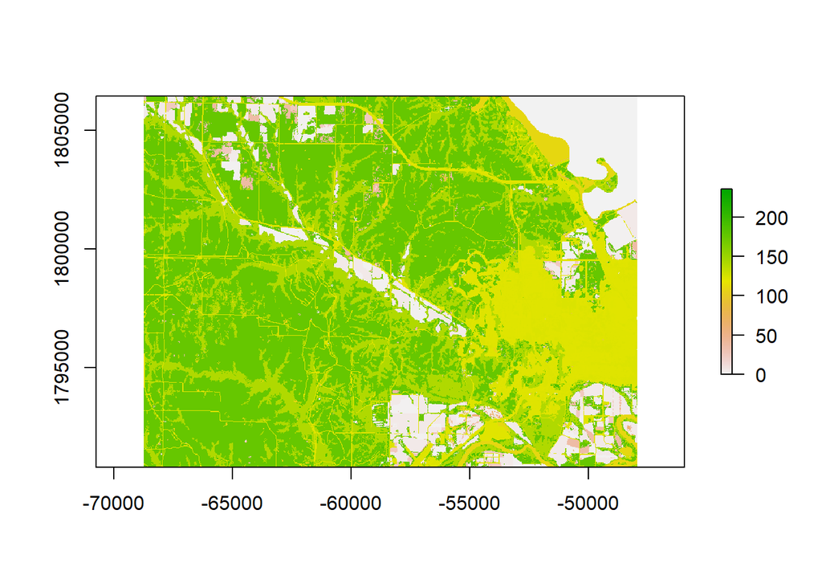

```r
# change crs and crop

## 2016
watershed <- st_transform(watershed, crs(CDL2016))
CDL2016_rc <- crop(CDL2016, watershed)

# Or i can do it like:
# plot(CDL2016, ext = extent(watershed))
plot(CDL2016_rc)
```

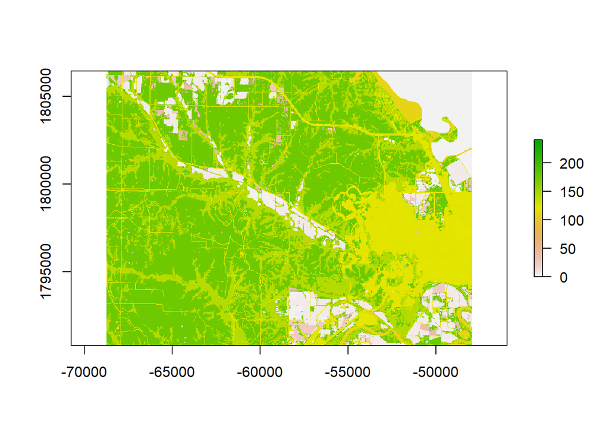

```r
## 2017
watershed <- st_transform(watershed, crs(CDL2017))
CDL2017_rc <- crop(CDL2017, watershed)

plot(CDL2017_rc)
```

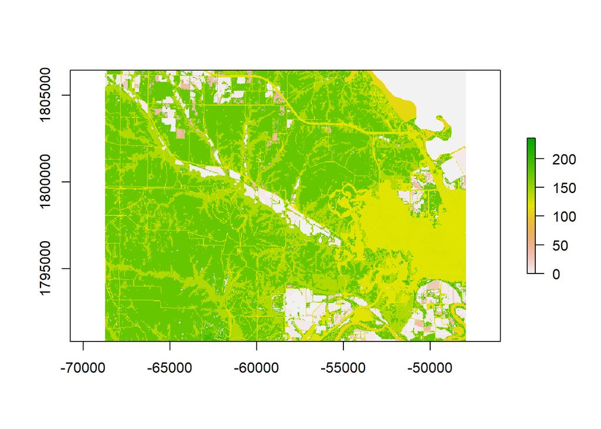

```r
## 2018
watershed <- st_transform(watershed, crs(CDL2018))
CDL2018_rc <- crop(CDL2018, watershed)

plot(CDL2018_rc)
```

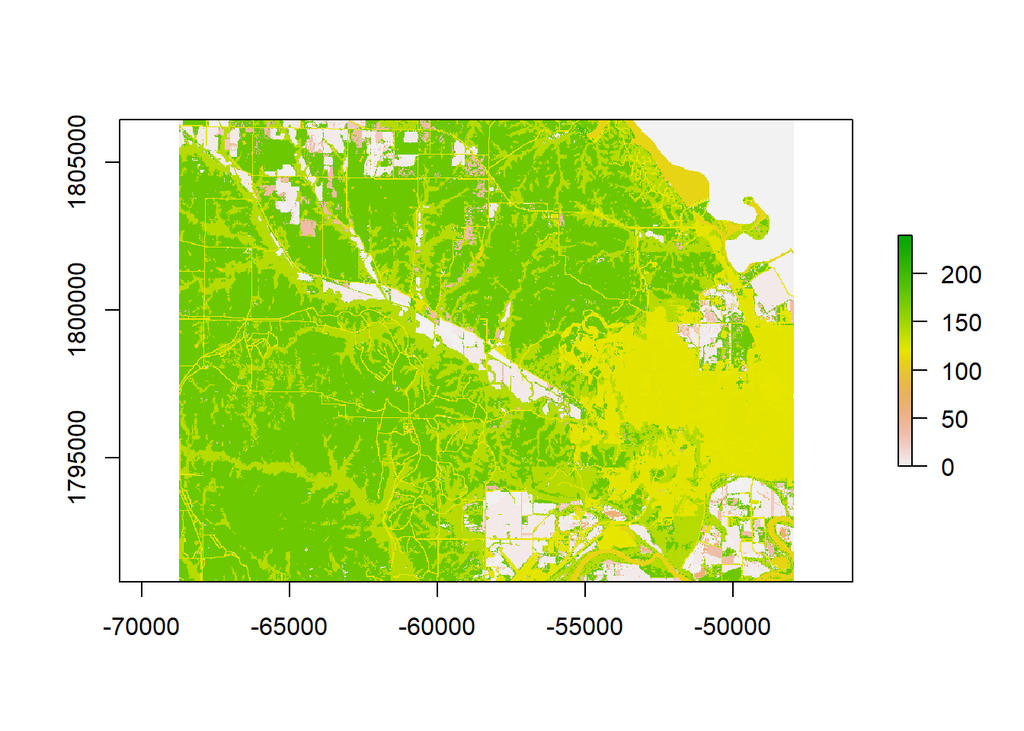

```r
## 2019
watershed <- st_transform(watershed, crs(CDL2019))
CDL2019_rc <- crop(CDL2019, watershed)

plot(CDL2019_rc)
```

## 2.

### Determine and report the most common landuse type in the wildcat creek watershed for each year.

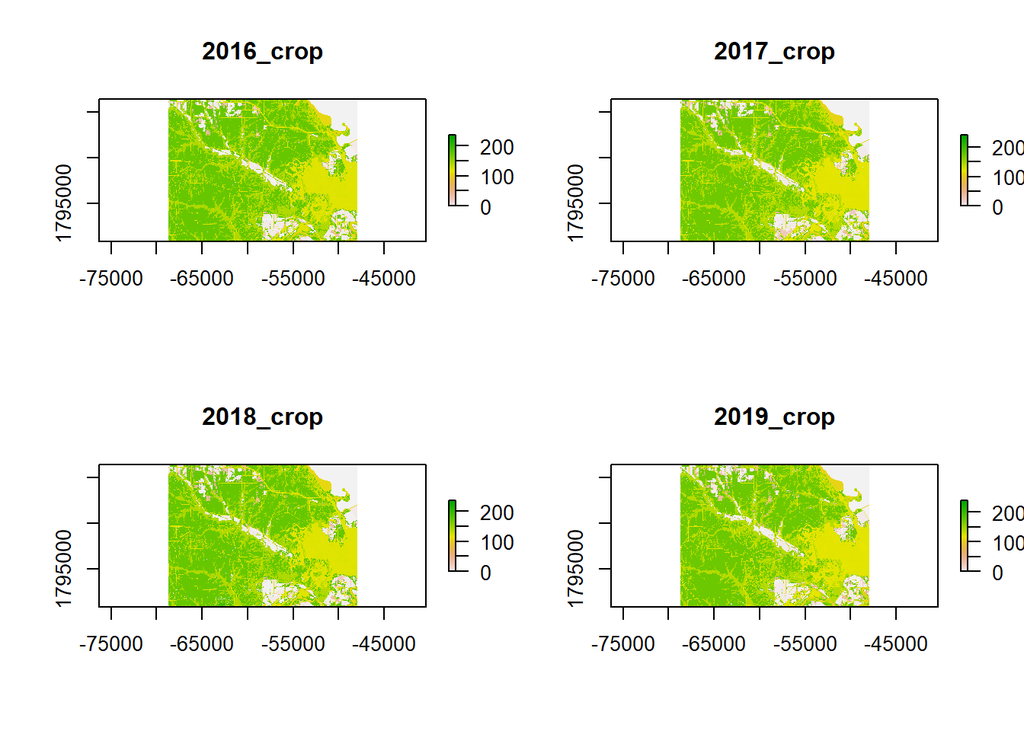

```r
attach(mtcars)
par(mfrow=c(2,2))
plot(CDL2016_rc, main = "2016_crop")
plot(CDL2017_rc, main = "2017_crop")
plot(CDL2018_rc, main = "2018_crop")
plot(CDL2019_rc, main = "2019_crop")
```

```r
land_types_2016 <- CDL2016@data@attributes[[1]]$CLASS_NAME
# land_type_2016_freq <- freq(land_types_2016)
# land_type_2016_freq <- table(land_types_2016)
# which.max(land_type_2016_freq)

most_common_2016 <- names(table(land_types_2016))[which.max(table(land_types_2016))]
most_common_2016
```

```
## [1] "Barren"
```

```r
land_types_2017 <- CDL2017@data@attributes[[1]]$CLASS_NAME
most_common_2017 <- names(table(land_types_2017))[which.max(table(land_types_2017))]
most_common_2017
```

```
## [1] "Barren"
```

```r
land_types_2018 <- CDL2018@data@attributes[[1]]$CLASS_NAME
most_common_2018 <- names(table(land_types_2018))[which.max(table(land_types_2018))]
most_common_2018
```

```
## [1] "Barren"
```

```r
land_types_2019 <- CDL2019@data@attributes[[1]]$CLASS_NAME
most_common_2019 <- names(table(land_types_2019))[which.max(table(land_types_2019))]
most_common_2019
```

```
## [1] "Barren"
```

## 3.

### Create and plot two new rasters. One that displays the locations where the land use type in 2016 and 2019 is different, and another that displays the most frequent land use type across all years (for the watershed).

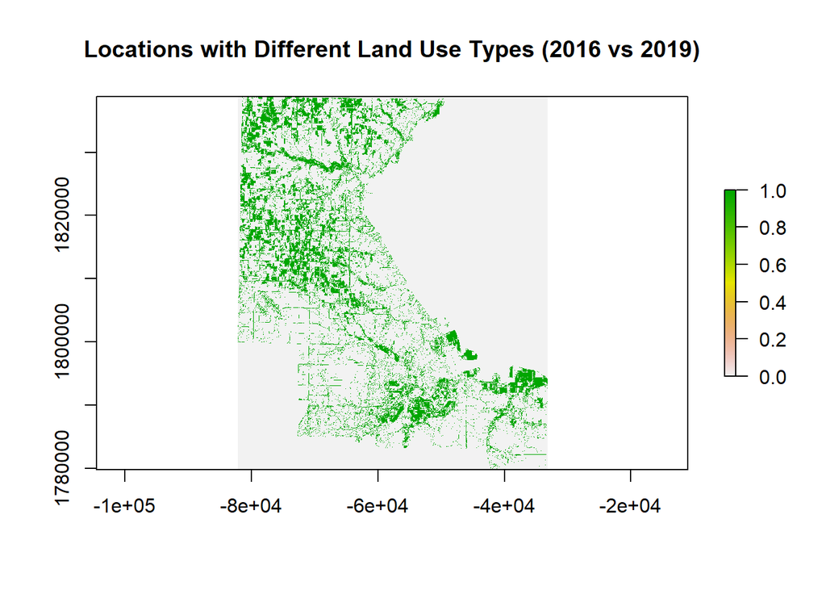

```r
# sec 1
diff_raster <- CDL2016
diff_raster[] <- ifelse(CDL2016[] != CDL2019[], 1, 0)

plot(diff_raster, main = "Locations with Different Land Use Types (2016 vs 2019)")
```

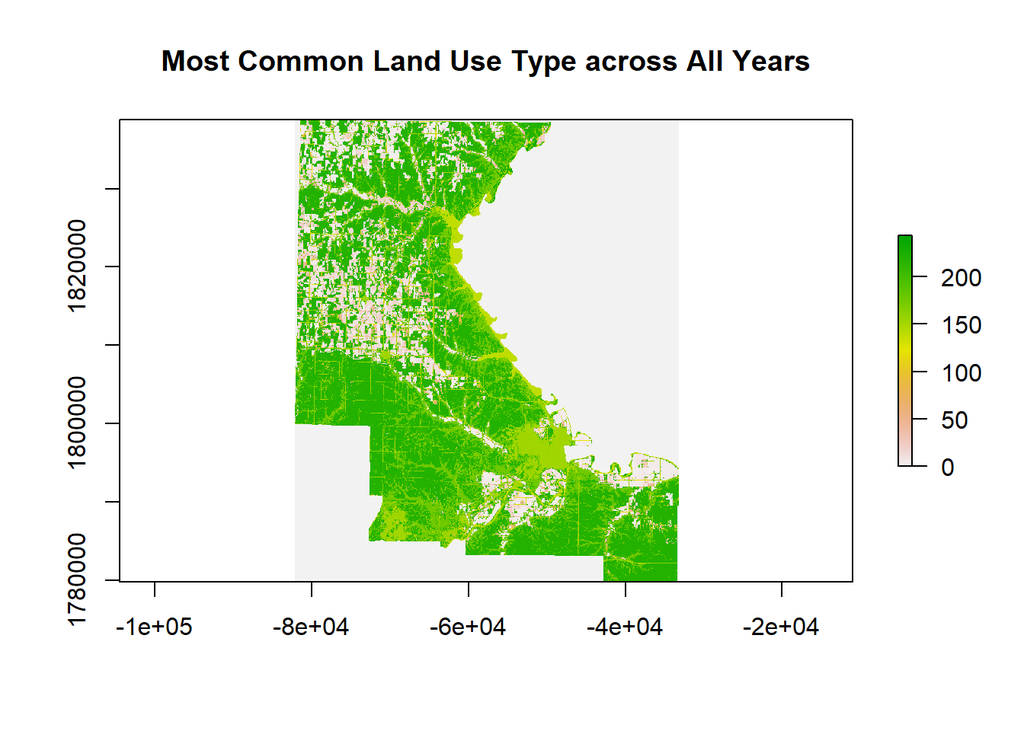

```r
# sec 2

most_common_raster <- CDL2016
years <- list(CDL2016, CDL2017, CDL2018, CDL2019)
for (year in years) {
  most_common_raster[] <- most_common_raster[] + year[]
}
most_common_raster <- most_common_raster / length(years)


plot(most_common_raster, main = "Most Common Land Use Type across All Years")
```

## 4.

### Increase the size of the raster grid cells by a factor of 10 for the 2019 watershed land use raster and plot it. What is the most common land use of this lower resolution (more coarse-grained) raster? Are all the same land uses that were in the high resolution raster found in this lower resolution raster?

From both plots, we can observe that the largest areas of land are represented by green-colored blocks.

```r
# it's 30*30
res(CDL2019)
```

```
## [1] 30 30
```

```r
CDL2019_10x <- aggregate(CDL2019, fact = 10, fun = modal, na.rm=T)
res(CDL2019_10x)
```

```
## [1] 300 300
```

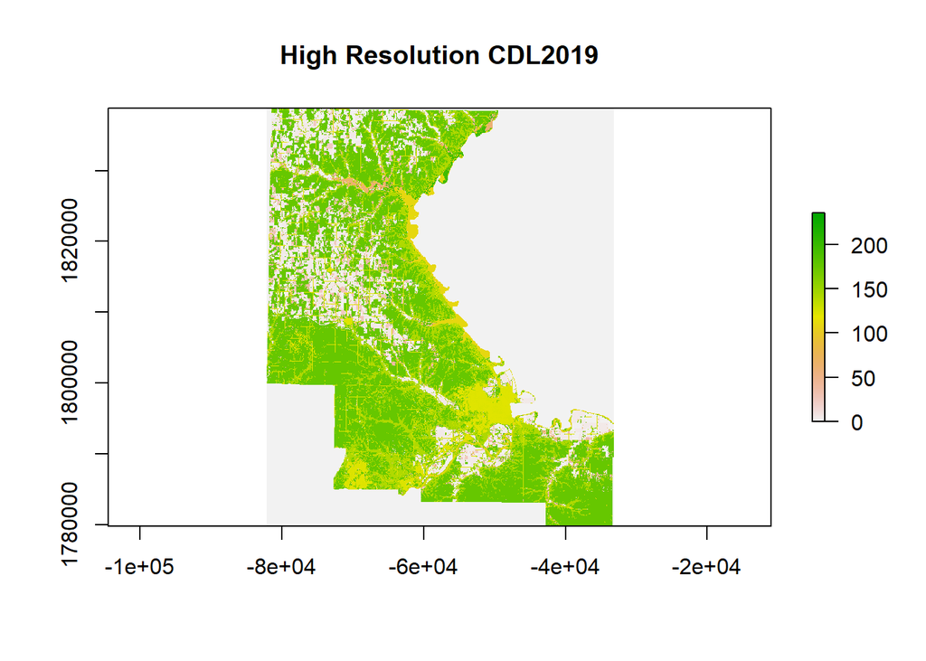

```r
plot(CDL2019, main = "High Resolution CDL2019")
```

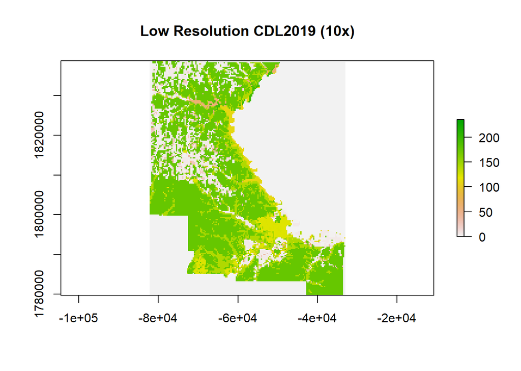

```r
plot(CDL2019_10x, main = "Low Resolution CDL2019 (10x)")
```

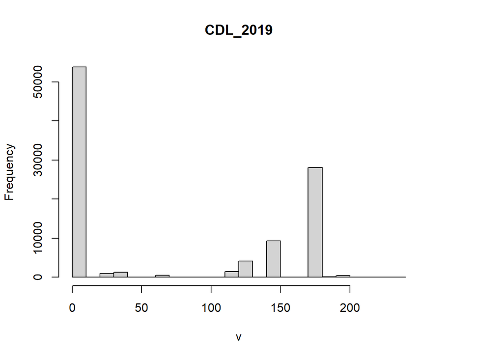

```r
hist(CDL2019, main = "CDL_2019")
```

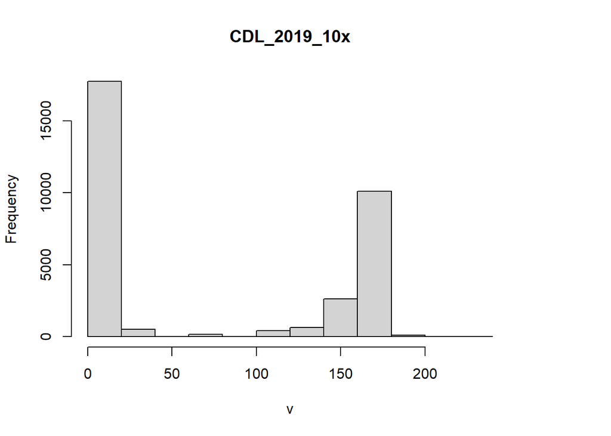

```r
hist(CDL2019_10x, main = "CDL_2019_10x")
```

## 5.

### Resample the 2019 watershed land use raster to a 1 kilometer grid and plot it. How does this even more coarse resolution raster compare to the original raster? Are the land uses the same?

From both plots, we can observe that the predominant color in the output image with lower resolution is a deep green, indicating a predominant land use, whereas the output image with higher resolution exhibits a variety of different land uses.

```r
# it's 30*30
res(CDL2019)
```

```
## [1] 30 30
```

```r
CDL2019_1k <- aggregate(CDL2019, fact = 33.3333, fun = modal, na.rm=T)
res(CDL2019_1k)
```

```
## [1] 990 990
```

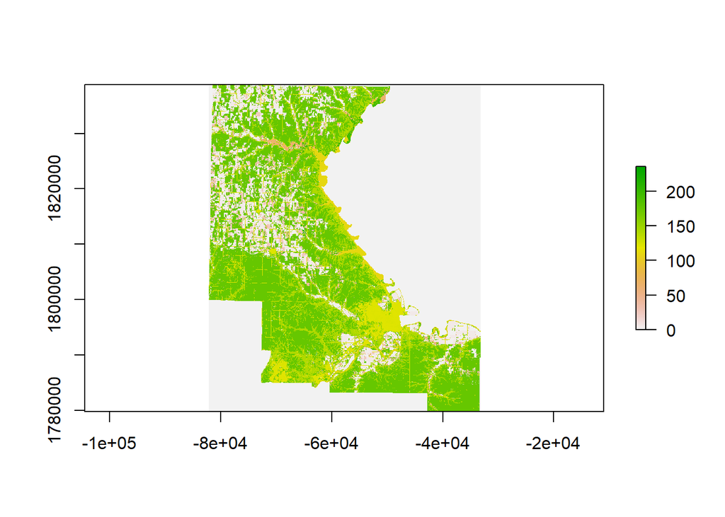

```r
plot(CDL2019)
```

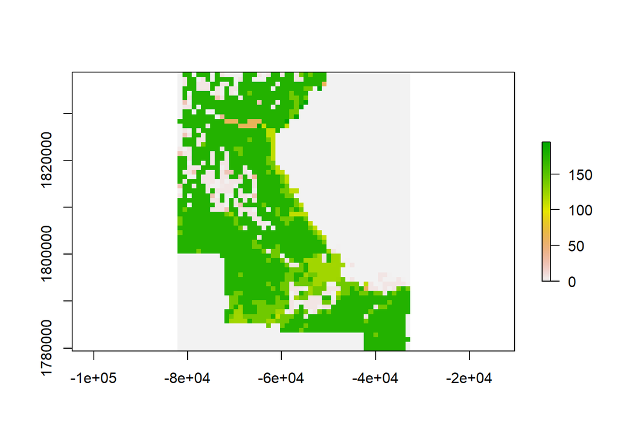

```r
plot(CDL2019_1k)
```

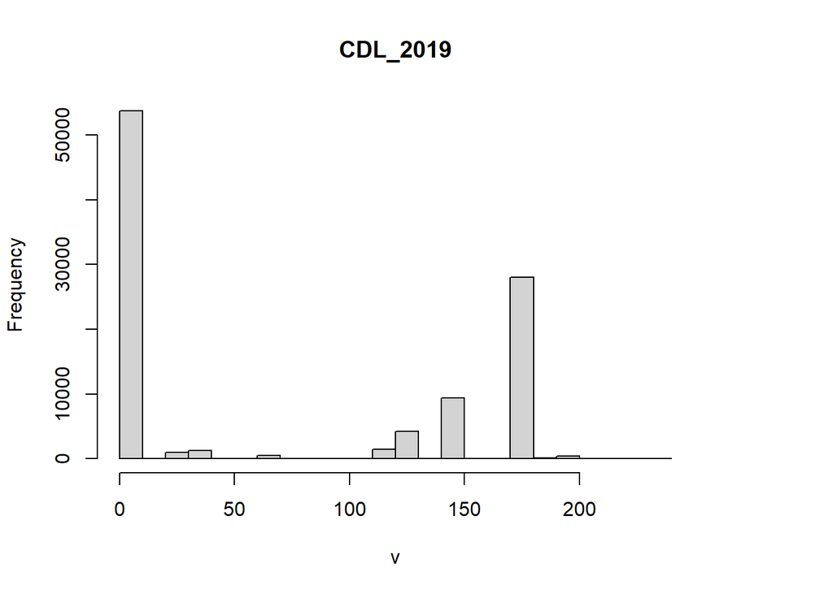

```r
hist(CDL2019, main = "CDL_2019")
```

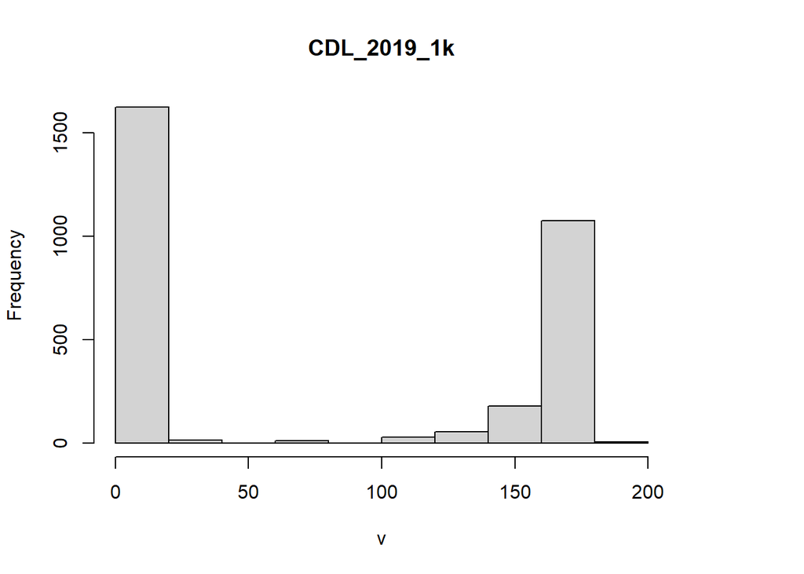

```r
hist(CDL2019_1k, main = "CDL_2019_1k")
```